# Example of a case series method for deaths and high heat days

Brooke Anderson

September 2, 2015

## Set-up

Required libraries:

```r
library(dplyr)
library(ggplot2)
library(tidyr)
library(gnm)
library(tsModel)
library(survival)
```

## Exploring the data

First, I read in the `heat_deaths` data, which I generated from the original `deaths` data using the R script `clean_heat_deaths.R`. I’ll limit this data just to date, maximum daily temperature, and number of heat deaths.

```r
heat_deaths <- read.csv("heat_deaths.csv") %>%
        dplyr::select(day, temp_max, heat_deaths) %>%
        mutate(day = as.Date(as.character(day)))
head(heat_deaths)
```

```
##          day temp_max heat_deaths
## 1 2008-01-01     17.8           0
## 2 2008-01-02      9.8           0
## 3 2008-01-03     15.6           0
## 4 2008-01-04     20.6           0
## 5 2008-01-05     21.3           0
## 6 2008-01-06     22.1           0
```

Over the year, there were 35 deaths coded X30 for “Exposure to excessive natural heat”:

```r
sum(heat_deaths$heat_deaths)
```

```
## [1] 35
```

Here is the distribution of the maximum temperatures:

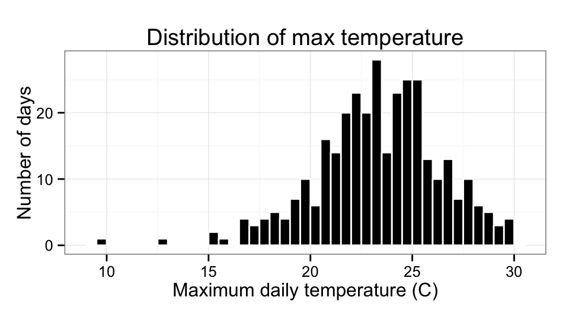

```r
ggplot(heat_deaths, aes(x = temp_max)) +
        geom_histogram(binwidth = 0.5, fill = "black",
                       colour = "white") +
        xlab("Maximum daily temperature (C)") +
        ylab("Number of days") +
        theme_bw() +
        ggtitle("Distribution of max temperature")
```

Here is a graph showing dates of missing data for temperature:

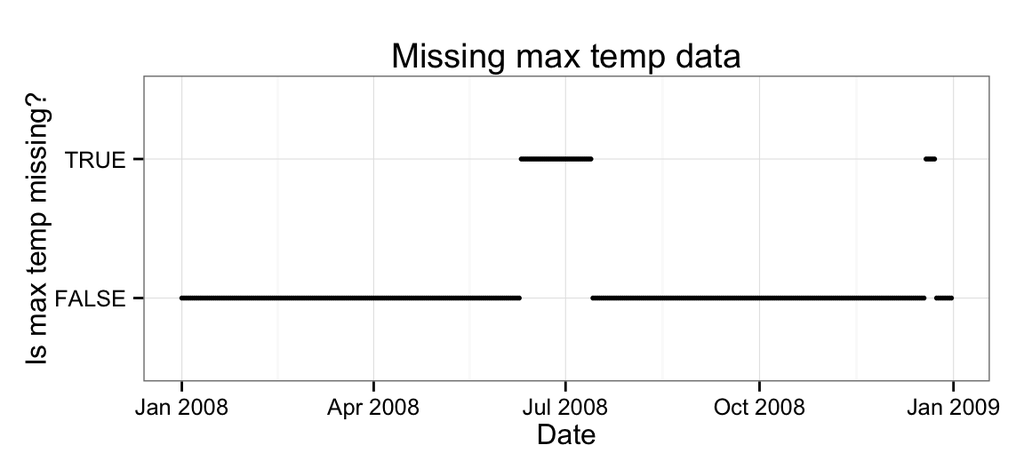

```r
ggplot(heat_deaths, aes(x = day, y = is.na(temp_max))) +
        geom_point(size = 1) +
        theme_bw() +
        xlab("Date") + ylab("Is max temp missing?") +
        ggtitle("Missing max temp data")
```

## Risk period

For this example, I’ll consider a day with maximum temperature 28C or higher a “heat day”. I’ll consider that this exposure creates an immediate (i.e., lag 0) risk, so the risk periods are the heat days:

```r
heat_deaths <- mutate(heat_deaths,
                      heat_day = temp_max >= 28)
summary(heat_deaths$heat_day)
```

```
##    Mode   FALSE    TRUE    NA's
## logical     309      18      39
```

From this, you can see that 18 days are risk periods, 309 days are not risk periods, and 39 days we can’t identify as risk periods or not, because the maximum temperature data is missing those days.

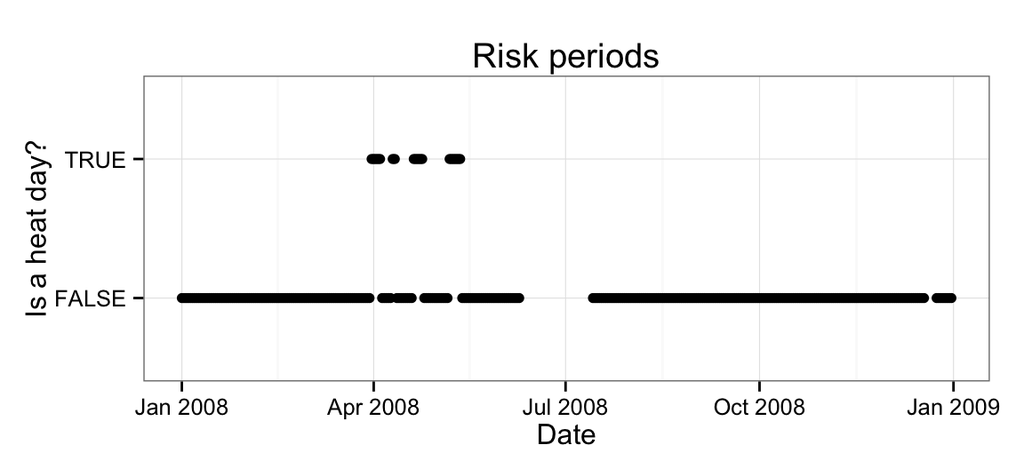

```r
ggplot(heat_deaths, aes(day, heat_day)) +
        geom_point() +
        theme_bw() +
        xlab("Date") + ylab("Is a heat day?") +
        ggtitle("Risk periods")
```

Interestingly, all of the risk periods for heat are in the late spring. If you plot out the maximum temperatures by date, you can see that this is consistent with temperature patterns (I’ve added a reference line at 28C and colored points by category as a risk period):

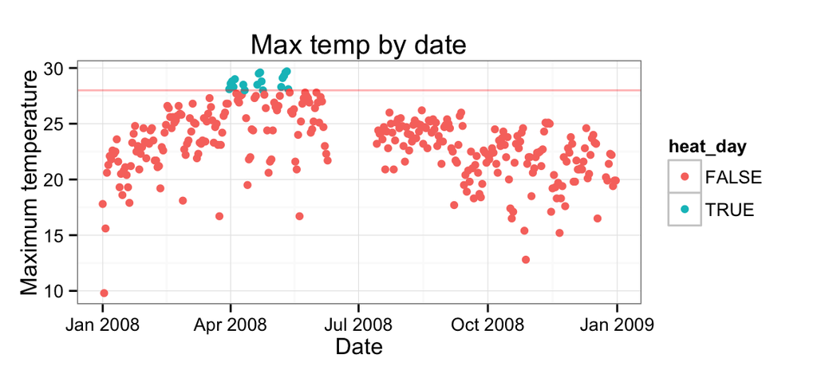

```r
ggplot(heat_deaths, aes(day, temp_max, colour = heat_day)) +
        geom_point() +
        theme_bw() +
        xlab("Date") + ylab("Maximum temperature") +
        ggtitle("Max temp by date") +
        geom_hline(yintercept = 28, alpha = 0.3, color = "red")
```

## Outcomes

In terms of the outcome (heat deaths), here is a plot of heat deaths by date (I’ve colored by whether we’re missing maximum temperature data for that day):

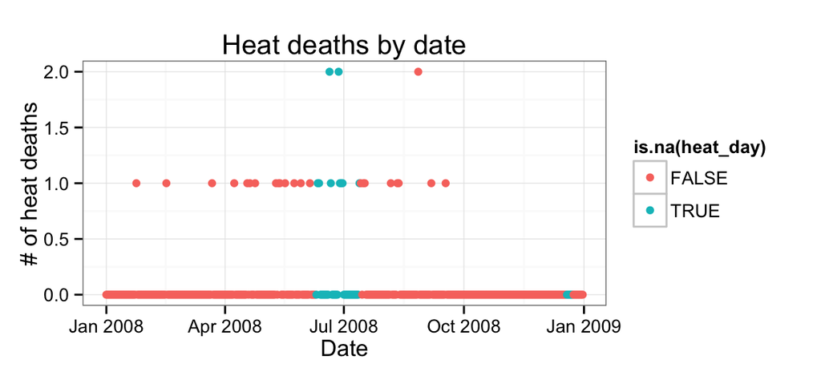

```r
ggplot(heat_deaths, aes(day, heat_deaths, color = is.na(heat_day))) +
        geom_point() +
        theme_bw() +
        xlab("Date") + ylab("# of heat deaths") +
        ggtitle("Heat deaths by date")
```

Heat deaths occurred through out the spring (even late winter in a few cases) and into the summer and early fall. The only days with multiple heat deaths were in the months June and August:

```r
subset(heat_deaths, heat_deaths > 1)
```

```
##            day temp_max heat_deaths heat_day
## 172 2008-06-20       NA           2       NA
## 179 2008-06-27       NA           2       NA
## 240 2008-08-27     23.9           2    FALSE
```

## Self-controlled case series

Next, I’ll take out the missing days and then create a summary table:

```r
heat_tab <- filter(heat_deaths, !is.na(temp_max)) %>%
        group_by(heat_day) %>%
        summarise(days = n(), events = sum(heat_deaths))
heat_tab
```

```
## Source: local data frame [2 x 3]
##
##   heat_day days events
## 1    FALSE  309     20
## 2     TRUE   18      4
```

Based on Whitaker et al.’s 2006 *Statistics in Medicine* article, I’ll fit this using a Poisson GLM:

```r
mod_1 <- glm(events ~ heat_day,
           offset = log(days),
           data = heat_tab,
           family = poisson(link = "log"))
summary(mod_1)
```

```
##
## Call:
## glm(formula = events ~ heat_day, family = poisson(link = "log"),
##     data = heat_tab, offset = log(days))
##
## Deviance Residuals:
## [1]  0  0
##
## Coefficients:
##              Estimate Std. Error z value Pr(>|z|)
## (Intercept)   -2.7376     0.2236 -12.243   <2e-16 ***
## heat_dayTRUE   1.2335     0.5477   2.252   0.0243 *
## ---
## Signif. codes:  0 '***' 0.001 '**' 0.01 '*' 0.05 '.' 0.1 ' ' 1
##
## (Dispersion parameter for poisson family taken to be 1)
##
##     Null deviance: 3.8345e+00  on 1  degrees of freedom
## Residual deviance: 1.7764e-15  on 0  degrees of freedom
## AIC: 12.108
##
## Number of Fisher Scoring iterations: 3
```

I can calculate the relative incidence by exponentiating the coefficient estimate for the `heat_day` variable:

```r
heat_coef <- summary(mod_1)$coef["heat_dayTRUE", 1:2]
heat_coef
```

```
##   Estimate Std. Error
##  1.2335316  0.5477225
```

```r
conf_int <- heat_coef[1] + c(-1, 1) * 1.96 * heat_coef[2]
conf_int
```

```
## [1] 0.1599954 2.3070678
```

```r
relative_incidence <- paste0(round(exp(heat_coef[1]), 1), " (",
                             round(exp(conf_int[1]), 1), ", ",
                             round(exp(conf_int[2]), 1), ")")
relative_incidence
```

```
## [1] "3.4 (1.2, 10)"
```

Therefore, we expect heat deaths to be about 3 times more common during risk periods from heat (as I’ve defined heat risk periods here) compared to outside of risk periods.

I think that we should get the same estimate if we apply the model to the uncollapsed data. In this case, it wouldn’t be necessary to include an offset for the number of days, since there is a separate observation for each day.

```r
mod_2 <- glm(heat_deaths ~ heat_day,
           data = heat_deaths,
           family = poisson(link = "log"))
summary(mod_2)
```

```
##
## Call:
## glm(formula = heat_deaths ~ heat_day, family = poisson(link = "log"),
##     data = heat_deaths)
##
## Deviance Residuals:
##     Min       1Q   Median       3Q      Max
## -0.6667  -0.3598  -0.3598  -0.3598   3.1389
##
## Coefficients:
##              Estimate Std. Error z value Pr(>|z|)
## (Intercept)   -2.7376     0.2236 -12.243   <2e-16 ***
## heat_dayTRUE   1.2335     0.5477   2.252   0.0243 *
## ---
## Signif. codes:  0 '***' 0.001 '**' 0.01 '*' 0.05 '.' 0.1 ' ' 1
##
## (Dispersion parameter for poisson family taken to be 1)
##
##     Null deviance: 128.14  on 326  degrees of freedom
## Residual deviance: 124.31  on 325  degrees of freedom
##   (39 observations deleted due to missingness)
## AIC: 174.92
##
## Number of Fisher Scoring iterations: 6
```

```r
heat_coef <- summary(mod_2)$coef["heat_dayTRUE", 1:2]
heat_coef
```

```
##   Estimate Std. Error
##  1.2335316  0.5477225
```

```r
conf_int <- heat_coef[1] + c(-1, 1) * 1.96 * heat_coef[2]
conf_int
```

```
## [1] 0.1599954 2.3070678
```

```r
relative_incidence <- paste0(round(exp(heat_coef[1]), 1), " (",
                             round(exp(conf_int[1]), 1), ", ",
                             round(exp(conf_int[2]), 1), ")")
relative_incidence
```

```
## [1] "3.4 (1.2, 10)"
```

This does result in exactly the same effect estimate.

## Adding in strata

Next, I’ll check out the relationship between heat risk days and cardiorespiratory deaths, using a stratification variable for month and day of week.

First, I’ll load the cardiorespiratory death data:

```r
cardioresp_deaths <- read.csv("cardioresp_deaths.csv") %>%
        dplyr::select(day, temp_max, cvd_deaths, resp_deaths) %>%
        mutate(day = as.Date(as.character(day)))
head(cardioresp_deaths)
```

```
##          day temp_max cvd_deaths resp_deaths
## 1 2008-01-01     17.8        424         186
## 2 2008-01-02      9.8        417         175
## 3 2008-01-03     15.6        437         171
## 4 2008-01-04     20.6        423         173
## 5 2008-01-05     21.3        427         182
## 6 2008-01-06     22.1        492         198
```

Here are plots for patterns by date in the counts of these two causes of death:

```r
to_plot <- gather(cardioresp_deaths, cause, deaths, -day, -temp_max)
to_plot$cause <- sub("_deaths", "", to_plot$cause)
head(to_plot)
```

```
##          day temp_max cause deaths
## 1 2008-01-01     17.8   cvd    424
## 2 2008-01-02      9.8   cvd    417
## 3 2008-01-03     15.6   cvd    437
## 4 2008-01-04     20.6   cvd    423
## 5 2008-01-05     21.3   cvd    427
## 6 2008-01-06     22.1   cvd    492
```

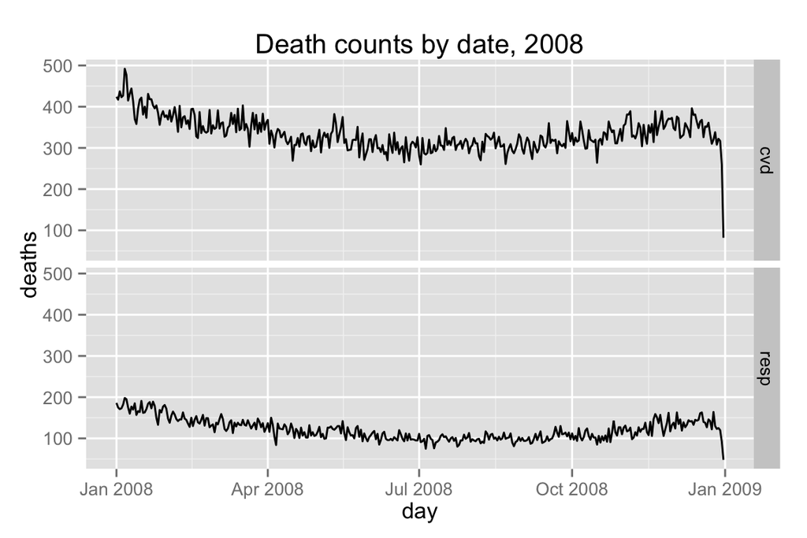

```r
ggplot(to_plot, aes(x = day, y = deaths)) +
        geom_line() +
        facet_grid(cause ~ .) +
        ggtitle("Death counts by date, 2008")
```

Based on this, there aren’t any days with no deaths for either of the two causes. Also, cardiovascular counts are consistently higher than respiratory counts.

I’ll limit the data we look at to March to September. Based on the earlier temperature plot, it seems that these dates would cover the “warm-season” for this location. Also, it looks like there might be some data quality issues in December, particularly at the very end of the month, so reducing to the warm season will eliminate this data.

```r
cardioresp_deaths <- filter(cardioresp_deaths,
                            months(day) %in% c("March", "April",
                                               "May", "June",
                                               "July", "August",
                                               "September"))
range(cardioresp_deaths$day)
```

```
## [1] "2008-03-01" "2008-09-30"
```

The baseline counts of deaths for both of these causes vary seasonally and by day of the week.

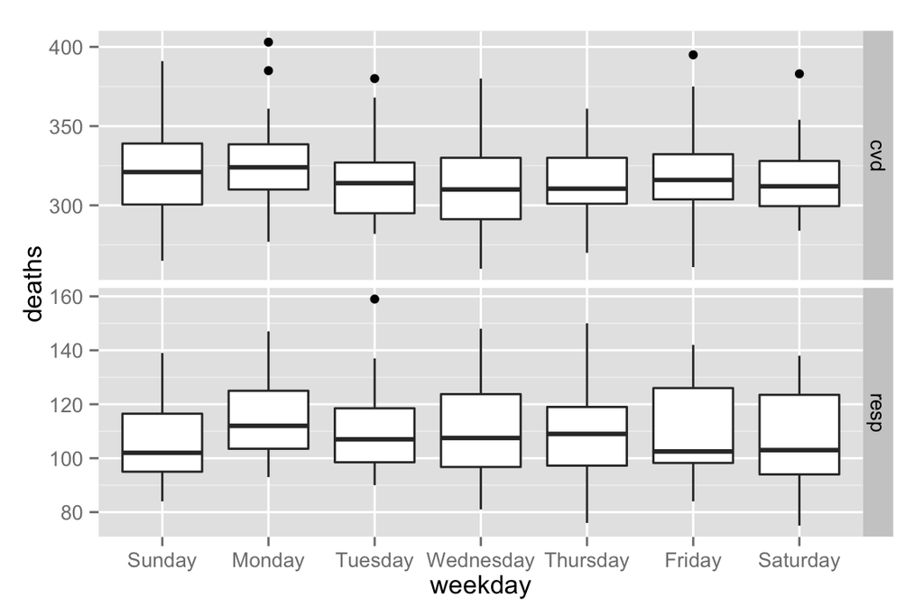

```r
to_plot <- gather(cardioresp_deaths, cause, deaths, -day, -temp_max)
to_plot$cause <- sub("_deaths", "", to_plot$cause)
to_plot <- mutate(to_plot,
                  weekday = factor(weekdays(day),
                                   levels = c("Sunday", "Monday",
                                              "Tuesday", "Wednesday",
                                              "Thursday", "Friday",
                                              "Saturday")),
                  month = factor(months(day),
                                 levels = c("March", "April",
                                            "May", "June",
                                            "July", "August",
                                            "September")))

ggplot(to_plot, aes(x = weekday, y = deaths)) +
        geom_boxplot() +
        facet_grid(cause ~ ., scales = "free_y")
```

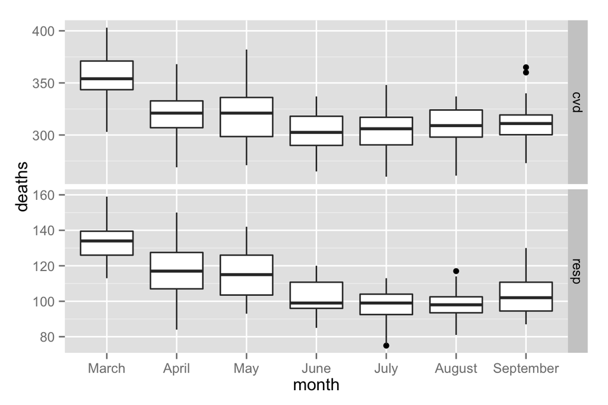

```r
ggplot(to_plot, aes(x = month, y = deaths)) +
        geom_boxplot() +
        facet_grid(cause ~ ., scales = "free_y")
```

There don’t seem to be large trends by day of the week, but there do seem to be large trends by month. I’ll try out doing Whitaker et al.’s (2006) case series model to explore the relationship between temperature and these two causes of mortality, including a stratum variable for month.

I’ll start by adding a variable for risk periods (defined as before as days with maximum temperature 28C or higher):

```r
cardioresp_deaths <- mutate(cardioresp_deaths,
                            heat_day = temp_max >= 28)
to_plot <- mutate(to_plot,
                  heat_day = temp_max >= 28)
```

Here is a plot of deaths by temperature for each cause and within each month. Color is used to show which days are “heat risk” days.

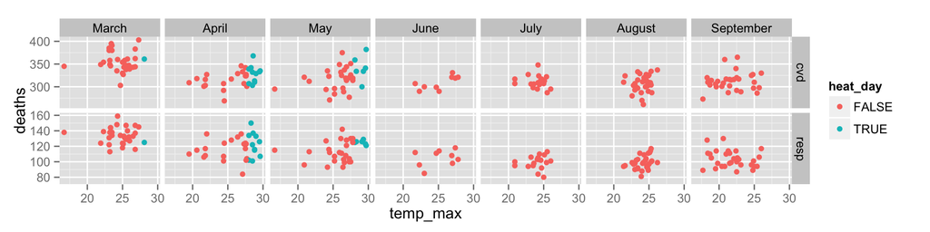

```r
ggplot(to_plot, aes(x = temp_max, y = deaths, color = heat_day)) +
        geom_point(size = 2) +
        facet_grid(cause ~ month, scales = "free_y")
```

The only months that have differences in exposure (i.e., some days in risk periods, some not) are the months of March, April, and May. I think that this means that we’d get the same final answer if we exclude all data from other months (*Note: is this right?*).

Let me start by fitting the model without putting `month` as a stratum.

```r
mod_3_cvd <- glm(cvd_deaths ~ heat_day,
             data = cardioresp_deaths,
             family = poisson(link = "log"))
summary(mod_3_cvd)$coef
```

```
##                Estimate  Std. Error    z value    Pr(>|z|)
## (Intercept)  5.76899592 0.004390558 1313.95503 0.000000000
## heat_dayTRUE 0.04380703 0.013613758    3.21785 0.001291554
```

```r
mod_3_resp <- glm(resp_deaths ~ heat_day,
             data = cardioresp_deaths,
             family = poisson(link = "log"))
summary(mod_3_resp)$coef
```

```
##               Estimate  Std. Error    z value     Pr(>|z|)
## (Intercept)  4.7073033 0.007465598 630.532688 0.000000e+00
## heat_dayTRUE 0.1066861 0.022507594   4.740006 2.137117e-06
```

Based on this model, the relative incidence for a risk period compared to a non-risk period is:

For cardiovascular deaths:

```r
cvd_coef <- summary(mod_3_cvd)$coef
point <- round((exp(cvd_coef[2, 1]) - 1) * 100, 1)
cis <- round((exp((cvd_coef[2, 1] +
                          c(-1, 1) * 1.96 * cvd_coef[2, 2])) - 1)
             * 100, 1)
paste0(point, "%, (", cis[1], ", ", cis[2], "%)")
```

```
## [1] "4.5%, (1.7, 7.3%)"
```

For respiratory deaths:

```r
resp_coef <- summary(mod_3_resp)$coef
point <- round((exp(resp_coef[2, 1]) - 1) * 100, 1)
cis <- round((exp((resp_coef[2, 1] +
                          c(-1, 1) * 1.96 * resp_coef[2, 2])) - 1)
             * 100, 1)
paste0(point, "%, (", cis[1], ", ", cis[2], "%)")
```

```
## [1] "11.3%, (6.5, 16.3%)"
```

And I think we should get the same values if we collapse all the data by risk period status and then fit a Poisson GLM with an offset included for the number of days in each risk class.

Here is the collapsed data for that:

```r
cardioresp_tab <- filter(cardioresp_deaths, !is.na(temp_max)) %>%
        group_by(heat_day) %>%
        summarise(days = n(),
                  cvd_events = sum(cvd_deaths),
                  resp_events = sum(resp_deaths))
cardioresp_tab
```

```
## Source: local data frame [2 x 4]
##
##   heat_day days cvd_events resp_events
## 1    FALSE  162      51875       17942
## 2     TRUE   18       6022        2218
```

And here are the models and results:

```r
mod_4_cvd <- glm(cvd_events ~ heat_day,
                 offset = log(days),
                 data = cardioresp_tab,
                 family = poisson(link = "log"))
summary(mod_4_cvd)$coef
```

```
##                Estimate Std. Error     z value    Pr(>|z|)
## (Intercept)  5.76899592 0.00439057 1313.951354 0.000000000
## heat_dayTRUE 0.04380703 0.01361378    3.217846 0.001291573
```

```r
mod_4_resp <- glm(resp_events ~ heat_day,
                 offset = log(days),
                 data = cardioresp_tab,
                 family = poisson(link = "log"))
summary(mod_4_resp)$coef
```

```
##               Estimate  Std. Error    z value     Pr(>|z|)
## (Intercept)  4.7073033 0.007465598 630.532687 0.000000e+00
## heat_dayTRUE 0.1066861 0.022507594   4.740006 2.137117e-06
```

Yep, this results in the same model coefficients for heat risk period.

### Poisson GLM fit with month strata

So, now I’ll try adding month as a stratum variable. First, I’ll add it into the Poisson GLM:

```r
cardioresp_deaths <- mutate(cardioresp_deaths,
                            month = factor(months(day),
                                           levels = c("March",
                                                      "April", "May",
                                                      "June", "July",
                                                      "August",
                                                      "September")))

mod_5_cvd <- glm(cvd_deaths ~ heat_day + month,
                 data = cardioresp_deaths,
                 family = poisson(link = "log"))
summary(mod_5_cvd)$coef
```

```
##                   Estimate  Std. Error    z value     Pr(>|z|)
## (Intercept)     5.87495091 0.009525154 616.782754 0.000000e+00
## heat_dayTRUE    0.05140018 0.015381577   3.341672 8.327546e-04
## monthApril     -0.12547234 0.014923650  -8.407617 4.184239e-17
## monthMay       -0.11185934 0.014050927  -7.960993 1.706635e-15
## monthJune      -0.14268897 0.021229686  -6.721200 1.802340e-11
## monthJuly      -0.13515800 0.016412304  -8.235163 1.793129e-16
## monthAugust    -0.14600387 0.013985105 -10.439955 1.628882e-25
## monthSeptember -0.13226829 0.014057035  -9.409402 4.989682e-21
```

```r
mod_5_resp <- glm(resp_deaths ~ heat_day + month,
                 data = cardioresp_deaths,
                 family = poisson(link = "log"))
summary(mod_5_resp)$coef
```

```
##                   Estimate Std. Error    z value     Pr(>|z|)
## (Intercept)     4.89503211 0.01554553 314.883658 0.000000e+00
## heat_dayTRUE    0.06270231 0.02539502   2.469079 1.354614e-02
## monthApril     -0.14779731 0.02451686  -6.028395 1.655955e-09
## monthMay       -0.16226621 0.02323372  -6.984082 2.867241e-12
## monthJune      -0.24107175 0.03605363  -6.686476 2.286084e-11
## monthJuly      -0.29599178 0.02829549 -10.460740 1.308302e-25
## monthAugust    -0.30056415 0.02382677 -12.614558 1.755404e-36
## monthSeptember -0.25642714 0.02374944 -10.797186 3.549162e-27
```

Now, the effect estimates for relative incidence are:

For cardiovascular deaths:

```r
cvd_coef <- summary(mod_5_cvd)$coef
point <- round((exp(cvd_coef[2, 1]) - 1) * 100, 1)
cis <- round((exp((cvd_coef[2, 1] +
                          c(-1, 1) * 1.96 * cvd_coef[2, 2])) - 1)
             * 100, 1)
paste0(point, "%, (", cis[1], ", ", cis[2], "%)")
```

```
## [1] "5.3%, (2.1, 8.5%)"
```

For respiratory deaths:

```r
resp_coef <- summary(mod_5_resp)$coef
point <- round((exp(resp_coef[2, 1]) - 1) * 100, 1)
cis <- round((exp((resp_coef[2, 1] +
                          c(-1, 1) * 1.96 * resp_coef[2, 2])) - 1)
             * 100, 1)
paste0(point, "%, (", cis[1], ", ", cis[2], "%)")
```

```
## [1] "6.5%, (1.3, 11.9%)"
```

The estimate for cardiovascular deaths has gone up a bit, and the one for respiratory deaths has gone down a bit.

### Collapsed data approach, with strata

Let’s see if we again get the exact same answer using a collapsed table version of the data, this time collapsed over risk period and month:

```r
cardioresp_tab <- filter(cardioresp_deaths, !is.na(temp_max)) %>%
        group_by(heat_day, month) %>%
        summarise(days = n(),
                  cvd_events = sum(cvd_deaths),
                  resp_events = sum(resp_deaths)) %>%
        filter(month %in% c("March", "April", "May"))
cardioresp_tab
```

```
## Source: local data frame [6 x 5]
## Groups: heat_day
##
##   heat_day month days cvd_events resp_events
## 1    FALSE March   30      10694        4026
## 2    FALSE April   19       5992        2197
## 3    FALSE   May   25       7919        2816
## 4     TRUE March    1        361         125
## 5     TRUE April   11       3611        1343
## 6     TRUE   May    6       2050         750
```

Note that I have taken out any month that did not have at least one day of each exposure type, which leaves only the months of March, April, and May.

Now I’ll fit a Poisson GLM with an offset of days to this collapsed data:

```r
mod_6_cvd <- glm(cvd_events ~ heat_day + month,
                 offset = log(days),
                 data = cardioresp_tab,
                 family = poisson(link = "log"))
summary(mod_6_cvd)$coef
```

```
##                 Estimate  Std. Error    z value     Pr(>|z|)
## (Intercept)   5.87495091 0.009525163 616.782188 0.000000e+00
## heat_dayTRUE  0.05140018 0.015381595   3.341668 8.327662e-04
## monthApril   -0.12547234 0.014923662  -8.407610 4.184492e-17
## monthMay     -0.11185934 0.014050950  -7.960981 1.706809e-15
```

```r
cvd_coef <- summary(mod_6_cvd)$coef
point <- round((exp(cvd_coef[2, 1]) - 1) * 100, 1)
cis <- round((exp((cvd_coef[2, 1] +
                          c(-1, 1) * 1.96 * cvd_coef[2, 2])) - 1)
             * 100, 1)
paste0(point, "%, (", cis[1], ", ", cis[2], "%)")
```

```
## [1] "5.3%, (2.1, 8.5%)"
```

```r
mod_6_resp <- glm(resp_events ~ heat_day + month,
                 offset = log(days),
                 data = cardioresp_tab,
                 family = poisson(link = "log"))
summary(mod_6_resp)$coef
```

```
##                 Estimate Std. Error    z value     Pr(>|z|)
## (Intercept)   4.89503211 0.01554553 314.883666 0.000000e+00
## heat_dayTRUE  0.06270231 0.02539502   2.469079 1.354613e-02
## monthApril   -0.14779731 0.02451686  -6.028396 1.655954e-09
## monthMay     -0.16226621 0.02323372  -6.984082 2.867237e-12
```

```r
resp_coef <- summary(mod_6_resp)$coef
point <- round((exp(resp_coef[2, 1]) - 1) * 100, 1)
cis <- round((exp((resp_coef[2, 1] +
                          c(-1, 1) * 1.96 * resp_coef[2, 2])) - 1)
             * 100, 1)
paste0(point, "%, (", cis[1], ", ", cis[2], "%)")
```

```
## [1] "6.5%, (1.3, 11.9%)"
```

This does give the same result as fitting the GLM to the data where there was one observation per date.

### Semi-expanded, then conditional logistic approach

Based on Armstrong et al.’s 2014 paper on conditional Poisson models, there should be two other equivalent ways we can fit this data. First, we should be able to “semi-expand” the data and then fit the model with a conditional logistic model, and we should also be able to use a conditional Poisson model to fit the data from a one-line-per-date format.

First, I’ll have to “semi-expand” the data, to make it so every day has one “case” day and then “control” days to match with every other day in its strata.

```r
month_days <- table(months(cardioresp_deaths$day))
month_days <- data_frame(month = names(month_days),
                         month_days = month_days)
strata <- cardioresp_deaths[ , c("day", "month")]
strata$date.strata <- as.character(strata$day)

semi_expand <- mutate(cardioresp_deaths,
                      month = months(cardioresp_deaths$day)) %>%
        left_join(month_days) %>%
        filter(month %in% c("March", "April", "May"))
for(i in 1:nrow(semi_expand)){
        df <- semi_expand[rep(i, each = semi_expand$month_days[i]), ]
        df$case_day <- c(1, rep(0,
                           length = semi_expand$month_days[i] - 1))
        df$case_con_set <- c(strata$date.strata[strata$day ==
                                                        df$day[1]],
                             strata$date.strata[strata$month ==
                                 df$month[1] & strata$day !=
                                         df$day[1]])
        if(i == 1){
                semi_expand_df <- df
        } else {
                semi_expand_df <- rbind(semi_expand_df, df)
        }
}

head(semi_expand_df)
```

```
##            day temp_max cvd_deaths resp_deaths heat_day month month_days
## 1   2008-03-01     23.2        349         138    FALSE March         31
## 1.1 2008-03-01     23.2        349         138    FALSE March         31
## 1.2 2008-03-01     23.2        349         138    FALSE March         31
## 1.3 2008-03-01     23.2        349         138    FALSE March         31
## 1.4 2008-03-01     23.2        349         138    FALSE March         31
## 1.5 2008-03-01     23.2        349         138    FALSE March         31
##     case_day case_con_set
## 1          1   2008-03-01
## 1.1        0   2008-03-02
## 1.2        0   2008-03-03
## 1.3        0   2008-03-04
## 1.4        0   2008-03-05
## 1.5        0   2008-03-06
```

```r
tail(semi_expand_df)
```

```
##              day temp_max cvd_deaths resp_deaths heat_day month month_days
## 92.25 2008-05-31     26.4        297          93    FALSE   May         31
## 92.26 2008-05-31     26.4        297          93    FALSE   May         31
## 92.27 2008-05-31     26.4        297          93    FALSE   May         31
## 92.28 2008-05-31     26.4        297          93    FALSE   May         31
## 92.29 2008-05-31     26.4        297          93    FALSE   May         31
## 92.30 2008-05-31     26.4        297          93    FALSE   May         31
##       case_day case_con_set
## 92.25        0   2008-05-25
## 92.26        0   2008-05-26
## 92.27        0   2008-05-27
## 92.28        0   2008-05-28
## 92.29        0   2008-05-29
## 92.30        0   2008-05-30
```

Now I’ll try fitting the conditional logistic regression to this semi-expanded data frame:

```r
timeout <- as.numeric(factor(semi_expand_df$case_con_set))
timein <- timeout - 0.1
mod_7_cvd <- coxph(Surv(timein, timeout, case_day) ~ heat_day,
                   weights = cvd_deaths,
                   data = semi_expand_df)
summary(mod_7_cvd)
```

```
## Call:
## coxph(formula = Surv(timein, timeout, case_day) ~ heat_day, data = semi_expand_df,
##     weights = cvd_deaths)
##
##   n= 2822, number of events= 92
##
##                   coef exp(coef)  se(coef) z Pr(>|z|)
## heat_dayTRUE 2.667e-15 1.000e+00 1.537e-02 0        1
##
##              exp(coef) exp(-coef) lower .95 upper .95
## heat_dayTRUE         1          1    0.9703     1.031
##
## Concordance= 0.5  (se = 0.001 )
## Rsquare= 0   (max possible= 1 )
## Likelihood ratio test= 0  on 1 df,   p=1
## Wald test            = 0  on 1 df,   p=1
## Score (logrank) test = 0  on 1 df,   p=1
```

This does not seem to be working correctly. I’ll need to check what’s going on here…

### Conditional Poisson approach

```r
mod_8_cvd <- gnm(cvd_deaths ~ heat_day,
                 data = cardioresp_deaths,
                 family = poisson,
                 eliminate = month)
summary(mod_8_cvd)$coef
```

```
##                Estimate Std. Error  z value     Pr(>|z|)
## heat_dayTRUE 0.05140018 0.01538159 3.341668 0.0008327663
```

```r
mod_8_resp <- gnm(resp_deaths ~ heat_day,
                 data = cardioresp_deaths,
                 family = poisson,
                 eliminate = month)
summary(mod_8_resp)$coef
```

```
##                Estimate Std. Error  z value   Pr(>|z|)
## heat_dayTRUE 0.06270231 0.02539502 2.469079 0.01354614
```

Yep, we get exactly the same results with this model.

With this model, we can also try out a model that allows for overdispersion, for example, for the cardiovascular deaths:

```r
mod_9_cvd <- gnm(cvd_deaths ~ heat_day,
                 data = cardioresp_deaths,
                 family = quasipoisson,
                 eliminate = month)
summary(mod_9_cvd)$coef
```

```
##                Estimate Std. Error  t value    Pr(>|t|)
## heat_dayTRUE 0.05140018 0.01738555 2.956489 0.003548871
```

```r
mod_9_resp <- gnm(resp_deaths ~ heat_day,
                 data = cardioresp_deaths,
                 family = quasipoisson,
                 eliminate = month)
summary(mod_9_resp)$coef
```

```
##                Estimate Std. Error  t value   Pr(>|t|)
## heat_dayTRUE 0.06270231 0.02666173 2.351772 0.01981628
```

Point estimates are almost exactly the same, but standard errors are a bit larger (and so confidence intervals would be a bit larger).

We can also use this model type to try out a model that includes adjustment for autocorrelation at lag 1 (using the Brumback autocorrelation adjustment):

```r
cardioresp_deaths <- filter(cardioresp_deaths,
                            !is.na(temp_max))
res_lag1 <- Lag(residuals(mod_9_cvd, type = "deviance"), 1)
mod_10_cvd <- gnm(cvd_deaths ~ heat_day + res_lag1,
                 data = cardioresp_deaths,
                 family = quasipoisson,
                 eliminate = month)
summary(mod_10_cvd)$coef
```

```
##                Estimate  Std. Error   t value    Pr(>|t|)
## heat_dayTRUE 0.05122049 0.017437637 2.9373529 0.003769561
## res_lag1     0.00383266 0.004260089 0.8996665 0.369570379
```

```r
res_lag1 <- Lag(residuals(mod_9_resp, type = "deviance"), 1)
mod_10_resp <- gnm(resp_deaths ~ heat_day + res_lag1,
                 data = cardioresp_deaths,
                 family = quasipoisson,
                 eliminate = month)
summary(mod_10_resp)$coef
```

```
##                Estimate  Std. Error  t value   Pr(>|t|)
## heat_dayTRUE 0.06520495 0.026642789 2.447377 0.01540705
## res_lag1     0.01249989 0.007199204 1.736287 0.08432470
```

Effect estimates have changed very little.